# Your first neural network

## Time to build the network

Below you'll build your network. We've built out the structure. You'll implement the forward pass and backward pass through the network. You'll also set the hyperparameters: the learning rate, the number of hidden units, and the number of training passes.

[figure not shown]

The network has two layers, a hidden layer and an output layer. The hidden layer will use the sigmoid function for activations. *The output layer has only one node and is used for the **regression**. The output of the node is **continuous** (number of rides) and the same as the input of the node. That is, the activation function is $f(x)=x$.* A function that takes the input signal and generates an output signal, but takes into account the threshold, is called an activation function. We work through each layer of our network calculating the outputs for each neuron. All of the outputs from one layer become inputs to the neurons on the next layer. This process is called *forward propagation*.

We use the weights to propagate signals forward from the input to the output layers in a neural network. We use the weights to also propagate error backwards from the output back into the network to update our weights. This is called *backpropagation*.

> **Hint:** You'll need the derivative of the output activation function ($f(x) = x$) for the backpropagation implementation. If you aren't familiar with calculus, this function is equivalent to the equation $y = x$. What is the slope of that equation? That is the derivative of $f(x)$.

Below, you have these tasks:

1. Implement the sigmoid function to use as the activation function. Set `self.activation_function` in `__init__` to your sigmoid function.
2. Implement the forward pass in the `train` method.
3. Implement the backpropagation algorithm in the `train` method, including calculating the output error.
4. Implement the forward pass in the `run` method.

```python
class NeuralNetwork(object):
    def __init__(self, input_nodes, hidden_nodes, output_nodes, learning_rate):
        # Set number of nodes in input, hidden and output layers.
        self.input_nodes = input_nodes
        self.hidden_nodes = hidden_nodes
        self.output_nodes = output_nodes

        # Initialize weights
        self.weights_input_to_hidden = np.random.normal(0.0, self.input_nodes**-0.5,
                                       (self.input_nodes, self.hidden_nodes))

        self.weights_hidden_to_output = np.random.normal(0.0, self.hidden_nodes**-0.5,
                                       (self.hidden_nodes, self.output_nodes))
        self.lr = learning_rate

        #### Set self.activation_function to sigmoid function ####
        #
        # Note: in Python, you can define a function with a lambda expression,
        # as shown below.
        self.activation_function = lambda x : 1 / (1 + np.exp( -x ))  # Replace 0 with your sigmoid calculation.

        ### If the lambda code above is not something you're familiar with,
        # You can uncomment out the following three lines and put your
        # implementation there instead.
        #
        #def sigmoid(x):
        #    return 0  # Replace 0 with your sigmoid calculation here
        #self.activation_function = sigmoid


    def train(self, features, targets):
        ''' Train the network on batch of features and targets.

            Arguments
            ---------

            features: 2D array, each row is one data record, each column is a feature
            targets: 1D array of target values

        '''
        n_records = features.shape[0]

        delta_weights_i_h = np.zeros(self.weights_input_to_hidden.shape)
        delta_weights_h_o = np.zeros(self.weights_hidden_to_output.shape)

        ## Training ##
        for X, y in zip(features, targets):
            ### Forward pass ###

            #### Hidden layer ####
            hidden_inputs = np.dot(X, self.weights_input_to_hidden)  # signals into hidden layer
            hidden_outputs = self.activation_function(hidden_inputs)  # signals from hidden layer

            #### Output layer ####
            final_inputs = np.dot(hidden_outputs, self.weights_hidden_to_output)  # signals into final output layer
            # Note: The output node is a regression node, so activation function is the identity f(x)=x
            final_outputs = final_inputs  # signals from final output layer

            ### Backward pass ###

            #### Output layer ####
            error = y - final_outputs  # Output layer error is the difference between desired target and actual output.
            # Note: The derivative of f(x)=x is 1
            output_error_term = error * 1.0

#             print("DEBUG: error={}".format(error))

            #### Hidden layer ####
            # The shape of the hidden layer's error is the same as the shape of the hidden layer output
            hidden_error = output_error_term * self.weights_hidden_to_output
            # The shape of hidden error term should be such that X.T * delta_h should have the shape of i2h
            # Note: Efficiency shortcut using the fact that sig_prime(x) = sig(x) * (1-sig(x))
            hidden_error_term = (hidden_outputs * (1-hidden_outputs)) * hidden_error.T

            ### Weight step ###

            # Input to hidden)
            delta_weights_i_h += X[:, None] * hidden_error_term

            # Hidden to output)
            delta_weights_h_o += output_error_term * hidden_outputs[:, None]

        ## Weight update ##
        self.weights_hidden_to_output += self.lr * delta_weights_h_o / n_records  # update hidden-to-output weights with gradient descent step
        self.weights_input_to_hidden += self.lr * delta_weights_i_h / n_records  # update input-to-hidden weights with gradient descent step

    def run(self, features):
        ''' Run a forward pass through the network with input features

            Arguments
            ---------
            features: 1D array of feature values
        '''

        ## Forward pass ##
        # Hidden layer
        hidden_inputs = features.dot(self.weights_input_to_hidden) # signals into hidden layer
        hidden_outputs = self.activation_function(hidden_inputs) # signals from hidden layer

        # Output layer
        final_inputs = hidden_outputs.dot(self.weights_hidden_to_output) # signals into final output layer
        final_outputs = final_inputs # signals from final output layer

        return final_outputs  # Note: If 'features' is a pd.DF, so is 'final_outputs'!
```

```python
def MSE(y, Y):
    return np.mean((y - Y)**2)
```

## Unit tests

Run these unit tests to check the correctness of your network implementation. This will help you be sure your network was implemented correctly befor you starting trying to train it. These tests must all be successful to pass the project.

```python
import unittest

# seed the random module for repeatability
np.random.seed(41)

inputs = np.array([[0.5, -0.2, 0.1]])
targets = np.array([[0.4]])
test_w_i_h = np.array([[0.1, -0.2],
                       [0.4, 0.5],
                       [-0.3, 0.2]])
test_w_h_o = np.array([[0.3],
                       [-0.1]])

class TestMethods(unittest.TestCase):

    ##########
    # Unit tests for data loading
    ##########

    def test_data_path(self):
        # Test that file path to dataset has been unaltered
        self.assertTrue(data_path.lower() == 'bike-sharing-dataset/hour.csv')

    def test_data_loaded(self):
        # Test that data frame loaded
        self.assertTrue(isinstance(rides, pd.DataFrame))

    ##########
    # Unit tests for network functionality
    ##########

    def test_activation(self):
        network = NeuralNetwork(3, 2, 1, 0.5)
        # Test that the activation function is a sigmoid
        self.assertTrue(np.all(network.activation_function(0.5) == 1/(1+np.exp(-0.5))))

    def test_train(self):
        # Test that weights are updated correctly on training
        network = NeuralNetwork(3, 2, 1, 0.5)
        network.weights_input_to_hidden = test_w_i_h.copy()
        network.weights_hidden_to_output = test_w_h_o.copy()

        network.train(inputs, targets)
        self.assertTrue(np.allclose(network.weights_hidden_to_output,
                                    np.array([[ 0.37275328],
                                              [-0.03172939]])))
        self.assertTrue(np.allclose(network.weights_input_to_hidden,
                                    np.array([[ 0.10562014, -0.20185996],
                                              [0.39775194, 0.50074398],
                                              [-0.29887597, 0.19962801]])))

    def test_run(self):
        # Test correctness of run method
        network = NeuralNetwork(3, 2, 1, 0.5)
        network.weights_input_to_hidden = test_w_i_h.copy()
        network.weights_hidden_to_output = test_w_h_o.copy()

        self.assertTrue(np.allclose(network.run(inputs), 0.09998924))

suite = unittest.TestLoader().loadTestsFromModule(TestMethods())
unittest.TextTestRunner().run(suite)
```

```
.....
----------------------------------------------------------------------
Ran 5 tests in 0.004s

OK
```

```
<unittest.runner.TextTestResult run=5 errors=0 failures=0>
```

## Training the network

Here you'll set the hyperparameters for the network. The strategy here is to find hyperparameters such that the error on the training set is low, but you're not overfitting to the data. If you train the network too long or have too many hidden nodes, it can become overly specific to the training set and will fail to generalize to the validation set. That is, the loss on the validation set will start increasing as the training set loss drops.

You'll also be using a method know as Stochastic Gradient Descent (SGD) to train the network. The idea is that for each training pass, you grab a random sample of the data instead of using the whole data set. You use many more training passes than with normal gradient descent, but each pass is much faster. This ends up training the network more efficiently. You'll learn more about SGD later.

### Choose the number of iterations

This is the number of batches of samples from the training data we'll use to train the network. The more iterations you use, the better the model will fit the data. However, if you use too many iterations, then the model with not generalize well to other data, this is called overfitting. You want to find a number here where the network has a low training loss, and the validation loss is at a minimum. As you start overfitting, you'll see the training loss continue to decrease while the validation loss starts to increase.

### Choose the learning rate

This scales the size of weight updates. If this is too big, the weights tend to explode and the network fails to fit the data. A good choice to start at is 0.1. If the network has problems fitting the data, try reducing the learning rate. Note that the lower the learning rate, the smaller the steps are in the weight updates and the longer it takes for the neural network to converge.

### Choose the number of hidden nodes

The more hidden nodes you have, the more accurate predictions the model will make. Try a few different numbers and see how it affects the performance. You can look at the losses dictionary for a metric of the network performance. If the number of hidden units is too low, then the model won't have enough space to learn and if it is too high there are too many options for the direction that the learning can take. The trick here is to find the right balance in number of hidden units you choose.

### Explore the parameter space

There are three hyperparameters to tweak in this NN model (value set in brackets):

1. Number of hidden nodes (`[2, 3, 4, 5, 6, 7, 8, 9, 10]`).
2. Learning rate (`[0.001, 0.005, 0.01, 0.05, 0.1, 0.5]`).
3. Number of training iterations (`[100, 500, 1000, 5000, 10000, 50000, 100000, 500000]`). The code cell below will explore this parameter space and record the *training and validation loss* for each parameter combination. The value sets for learning rate and training iterations were picked to be *logarithmic* to cover larger swaths of the parameter space.

```python
import sys
from tqdm import tnrange, tqdm_notebook

### Set the hyperparameters here ###
# iterations = [1000, 5000]
# learning_rate = [0.01, 0.1]
# hidden_nodes = [2, 3, 4]
# output_nodes = 1
iterations = [100, 500, 1000, 5000, 10000, 50000, 100000, 500000] # 8
learning_rate = [0.001, 0.005, 0.01, 0.05, 0.1, 0.5]              # 6
hidden_nodes = [2, 3, 4, 5, 6, 7, 8, 9, 10]                       # 9
output_nodes = 1

N_i = train_features.shape[1]

all_losses = {}
for hh in tqdm_notebook(hidden_nodes, desc='Hidden nodes'):

    for ll in tqdm_notebook(learning_rate, desc='Learning rate'):

        for it in tqdm_notebook(iterations, desc='Iterations'):

            # TODO: Mini-batch, weight-update variations, different neurons
            network = NeuralNetwork(N_i, hh, output_nodes, ll)
            losses = {'network':network, 'train':[], 'validation':[]}

            for ii in tnrange(it):

                # Go through a random batch of 128 records from the training data set
                batch = np.random.choice(train_features.index, size=128)
                # Note: ix[] is deprecated, using iloc[]
                X, y = train_features.loc[batch].values, train_targets.iloc[batch]['cnt']

                network.train(X, y)  # TODO: Mini-batch, weight-update variations, different neurons

                # Note: Because train_features is a pd.DF, so is the result of NN.run(), and this screws up np.mean()
                train_loss = MSE(network.run(train_features.values).T, train_targets['cnt'].values)
                val_loss   = MSE(network.run(val_features.values).T, val_targets['cnt'].values)

                sys.stdout.write("\rProgress ({0:2d}, {1:5.3f}, {2:6d}): {3:5.1f}% ... Training loss: {4:5.3f} ... Validation loss: {5:5.3f}".format(\
                                 hh, ll, it,
                                 100 * ii/float(it),
                                 train_loss,
                                 val_loss))
                sys.stdout.flush()

                losses['train'].append(train_loss)
                losses['validation'].append(val_loss)

            all_losses[(hh, ll, it)] = losses
```

```
Progress ( 2, 0.001,    100):  99.0% ... Training loss: 1.014 ... Validation loss: 1.652
```

```
Progress ( 2, 0.001,    500):  99.8% ... Training loss: 1.236 ... Validation loss: 1.350
```

```
Progress ( 2, 0.001,   1000):  99.9% ... Training loss: 1.055 ... Validation loss: 1.278
```

```
Progress ( 2, 0.001,   5000): 100.0% ... Training loss: 0.953 ... Validation loss: 1.368
```

```
Progress ( 2, 0.001,  10000): 100.0% ... Training loss: 0.961 ... Validation loss: 1.309
```

```
Progress ( 2, 0.001,  50000): 100.0% ... Training loss: 0.510 ... Validation loss: 0.837
```

```
Progress ( 2, 0.001, 100000): 100.0% ... Training loss: 0.306 ... Validation loss: 0.495
```

```
Progress ( 2, 0.001, 500000): 100.0% ... Training loss: 0.220 ... Validation loss: 0.372
```

```
Progress ( 2, 0.005,    100):  99.0% ... Training loss: 1.048 ... Validation loss: 1.274
```

```
Progress ( 2, 0.005,    500):  99.8% ... Training loss: 0.979 ... Validation loss: 1.333
```

```
Progress ( 2, 0.005,   1000):  99.9% ... Training loss: 0.973 ... Validation loss: 1.387
```

```
Progress ( 2, 0.005,   5000): 100.0% ... Training loss: 0.659 ... Validation loss: 1.097
```

```
Progress ( 2, 0.005,  10000): 100.0% ... Training loss: 0.569 ... Validation loss: 0.972
```

```
Progress ( 2, 0.005,  50000): 100.0% ... Training loss: 0.268 ... Validation loss: 0.440
```

```
Progress ( 2, 0.005, 100000): 100.0% ... Training loss: 0.236 ... Validation loss: 0.400
```

```
Progress ( 2, 0.005, 500000): 100.0% ... Training loss: 0.161 ... Validation loss: 0.305
```

```
Progress ( 2, 0.010,    100):  99.0% ... Training loss: 0.952 ... Validation loss: 1.467
```

```
Progress ( 2, 0.010,    500):  99.8% ... Training loss: 0.654 ... Validation loss: 1.068
```

```
Progress ( 2, 0.010,   1000):  99.9% ... Training loss: 0.875 ... Validation loss: 1.342
```

```
Progress ( 2, 0.010,   5000): 100.0% ... Training loss: 0.486 ... Validation loss: 0.796
```

```
Progress ( 2, 0.010,  10000): 100.0% ... Training loss: 0.367 ... Validation loss: 0.608
```

```
Progress ( 2, 0.010,  50000): 100.0% ... Training loss: 0.247 ... Validation loss: 0.409
```

```
Progress ( 2, 0.010, 100000): 100.0% ... Training loss: 0.220 ... Validation loss: 0.375
```

```
Progress ( 2, 0.010, 500000): 100.0% ... Training loss: 0.127 ... Validation loss: 0.232
```

```
Progress ( 2, 0.050,    100):  99.0% ... Training loss: 0.937 ... Validation loss: 1.316
```

```
Progress ( 2, 0.050,    500):  99.8% ... Training loss: 0.554 ... Validation loss: 0.903
```

```
Progress ( 2, 0.050,   1000):  99.9% ... Training loss: 0.436 ... Validation loss: 0.701
```

```
Progress ( 2, 0.050,   5000): 100.0% ... Training loss: 0.259 ... Validation loss: 0.425
```

```
Progress ( 2, 0.050,  10000): 100.0% ... Training loss: 0.244 ... Validation loss: 0.403
```

```
Progress ( 2, 0.050,  50000): 100.0% ... Training loss: 0.182 ... Validation loss: 0.279
```

```
Progress ( 2, 0.050, 100000): 100.0% ... Training loss: 0.136 ... Validation loss: 0.257
```

```
Progress ( 2, 0.050, 500000): 100.0% ... Training loss: 0.136 ... Validation loss: 0.248
```

```
Progress ( 2, 0.100,    100):  99.0% ... Training loss: 0.852 ... Validation loss: 1.320
```

```
Progress ( 2, 0.100,    500):  99.8% ... Training loss: 0.441 ... Validation loss: 0.714
```

```
Progress ( 2, 0.100,   1000):  99.9% ... Training loss: 0.313 ... Validation loss: 0.504
```

```
Progress ( 2, 0.100,   5000): 100.0% ... Training loss: 0.236 ... Validation loss: 0.394
```

```
Progress ( 2, 0.100,  10000): 100.0% ... Training loss: 0.221 ... Validation loss: 0.385
```

```
Progress ( 2, 0.100,  50000): 100.0% ... Training loss: 0.132 ... Validation loss: 0.237
```

```
Progress ( 2, 0.100, 100000): 100.0% ... Training loss: 0.093 ... Validation loss: 0.175
```

```
Progress ( 2, 0.100, 500000): 100.0% ... Training loss: 0.116 ... Validation loss: 0.215
```

```
Progress ( 2, 0.500,    100):  99.0% ... Training loss: 0.445 ... Validation loss: 0.717
```

```
Progress ( 2, 0.500,    500):  99.8% ... Training loss: 0.262 ... Validation loss: 0.428
```

```
Progress ( 2, 0.500,   1000):  99.9% ... Training loss: 0.215 ... Validation loss: 0.356
```

```
Progress ( 2, 0.500,   5000): 100.0% ... Training loss: 0.176 ... Validation loss: 0.332
```

```
Progress ( 2, 0.500,  10000): 100.0% ... Training loss: 0.141 ... Validation loss: 0.250
```

```
Progress ( 2, 0.500,  50000): 100.0% ... Training loss: 0.132 ... Validation loss: 0.246
```

```
Progress ( 2, 0.500, 100000): 100.0% ... Training loss: 0.132 ... Validation loss: 0.230
```

```
Progress ( 2, 0.500, 500000): 100.0% ... Training loss: 0.139 ... Validation loss: 0.260
```

```
Progress ( 3, 0.001,    100):  99.0% ... Training loss: 1.234 ... Validation loss: 1.949
```

```
Progress ( 3, 0.001,    500):  99.8% ... Training loss: 0.950 ... Validation loss: 1.418
```

```
Progress ( 3, 0.001,   1000):  99.9% ... Training loss: 1.007 ... Validation loss: 1.602
```

```
Progress ( 3, 0.001,   5000): 100.0% ... Training loss: 0.903 ... Validation loss: 1.350
```

```
Progress ( 3, 0.001,  10000): 100.0% ... Training loss: 0.791 ... Validation loss: 1.247
```

```
Progress ( 3, 0.001,  50000): 100.0% ... Training loss: 0.475 ... Validation loss: 0.777
```

```
Progress ( 3, 0.001, 100000): 100.0% ... Training loss: 0.320 ... Validation loss: 0.516
```

```
Progress ( 3, 0.001, 500000): 100.0% ... Training loss: 0.236 ... Validation loss: 0.403
```

```
Progress ( 3, 0.005,    100):  99.0% ... Training loss: 0.989 ... Validation loss: 1.695
```

```
Progress ( 3, 0.005,    500):  99.8% ... Training loss: 0.962 ... Validation loss: 1.320
```

```
Progress ( 3, 0.005,   1000):  99.9% ... Training loss: 0.729 ... Validation loss: 1.238
```

```
Progress ( 3, 0.005,   5000): 100.0% ... Training loss: 0.585 ... Validation loss: 1.012
```

```
Progress ( 3, 0.005,  10000): 100.0% ... Training loss: 0.525 ... Validation loss: 0.883
```

```
Progress ( 3, 0.005,  50000): 100.0% ... Training loss: 0.264 ... Validation loss: 0.430
```

```
Progress ( 3, 0.005, 100000): 100.0% ... Training loss: 0.240 ... Validation loss: 0.407
```

```
Progress ( 3, 0.005, 500000): 100.0% ... Training loss: 0.078 ... Validation loss: 0.164
```

```
Progress ( 3, 0.010,    100):  99.0% ... Training loss: 0.909 ... Validation loss: 1.388
```

```
Progress ( 3, 0.010,    500):  99.8% ... Training loss: 0.927 ... Validation loss: 1.340
```

```
Progress ( 3, 0.010,   1000):  99.9% ... Training loss: 0.673 ... Validation loss: 1.124
```

```
Progress ( 3, 0.010,   5000): 100.0% ... Training loss: 0.522 ... Validation loss: 0.869
```

```
Progress ( 3, 0.010,  10000): 100.0% ... Training loss: 0.308 ... Validation loss: 0.493
```

```
Progress ( 3, 0.010,  50000): 100.0% ... Training loss: 0.226 ... Validation loss: 0.404
```

```
Progress ( 3, 0.010, 100000): 100.0% ... Training loss: 0.197 ... Validation loss: 0.343
```

```
Progress ( 3, 0.010, 500000): 100.0% ... Training loss: 0.080 ... Validation loss: 0.165
```

```
Progress ( 3, 0.050,    100):  99.0% ... Training loss: 0.755 ... Validation loss: 1.255
```

```
Progress ( 3, 0.050,    500):  99.8% ... Training loss: 0.639 ... Validation loss: 1.081
```

```
Progress ( 3, 0.050,   1000):  99.9% ... Training loss: 0.390 ... Validation loss: 0.645
```

```
Progress ( 3, 0.050,   5000): 100.0% ... Training loss: 0.258 ... Validation loss: 0.422
```

```
Progress ( 3, 0.050,  10000): 100.0% ... Training loss: 0.234 ... Validation loss: 0.394
```

```
Progress ( 3, 0.050,  50000): 100.0% ... Training loss: 0.085 ... Validation loss: 0.168
```

```
Progress ( 3, 0.050, 100000): 100.0% ... Training loss: 0.080 ... Validation loss: 0.168
```

```
Progress ( 3, 0.050, 500000): 100.0% ... Training loss: 0.068 ... Validation loss: 0.138
```

```
Progress ( 3, 0.100,    100):  99.0% ... Training loss: 0.855 ... Validation loss: 1.360
```

```
Progress ( 3, 0.100,    500):  99.8% ... Training loss: 0.475 ... Validation loss: 0.778
```

```
Progress ( 3, 0.100,   1000):  99.9% ... Training loss: 0.303 ... Validation loss: 0.484
```

```
Progress ( 3, 0.100,   5000): 100.0% ... Training loss: 0.237 ... Validation loss: 0.400
```

```
Progress ( 3, 0.100,  10000): 100.0% ... Training loss: 0.180 ... Validation loss: 0.329
```

```
Progress ( 3, 0.100,  50000): 100.0% ... Training loss: 0.065 ... Validation loss: 0.138
```

```
Progress ( 3, 0.100, 100000): 100.0% ... Training loss: 0.062 ... Validation loss: 0.130
```

```
Progress ( 3, 0.100, 500000): 100.0% ... Training loss: 0.067 ... Validation loss: 0.138
```

```
Progress ( 3, 0.500,    100):  99.0% ... Training loss: 0.453 ... Validation loss: 0.742
```

```
Progress ( 3, 0.500,    500):  99.8% ... Training loss: 0.263 ... Validation loss: 0.428
```

```
Progress ( 3, 0.500,   1000):  99.9% ... Training loss: 0.246 ... Validation loss: 0.417
```

```
Progress ( 3, 0.500,   5000): 100.0% ... Training loss: 0.093 ... Validation loss: 0.173
```

```
Progress ( 3, 0.500,  10000): 100.0% ... Training loss: 0.077 ... Validation loss: 0.167
```

```
Progress ( 3, 0.500,  50000): 100.0% ... Training loss: 0.072 ... Validation loss: 0.145
```

```
Progress ( 3, 0.500, 100000): 100.0% ... Training loss: 0.063 ... Validation loss: 0.135
```

```
Progress ( 3, 0.500, 500000): 100.0% ... Training loss: 0.076 ... Validation loss: 0.151
```

```
Progress ( 4, 0.001,    100):  99.0% ... Training loss: 1.100 ... Validation loss: 1.632
```

```
Progress ( 4, 0.001,    500):  99.8% ... Training loss: 1.135 ... Validation loss: 1.304
```

```
Progress ( 4, 0.001,   1000):  99.9% ... Training loss: 0.904 ... Validation loss: 1.295
```

```
Progress ( 4, 0.001,   5000): 100.0% ... Training loss: 0.821 ... Validation loss: 1.241
```

```
Progress ( 4, 0.001,  10000): 100.0% ... Training loss: 0.726 ... Validation loss: 1.241
```

```
Progress ( 4, 0.001,  50000): 100.0% ... Training loss: 0.479 ... Validation loss: 0.787
```

```
Progress ( 4, 0.001, 100000): 100.0% ... Training loss: 0.306 ... Validation loss: 0.502
```

```
Progress ( 4, 0.001, 500000): 100.0% ... Training loss: 0.228 ... Validation loss: 0.397
```

```
Progress ( 4, 0.005,    100):  99.0% ... Training loss: 1.175 ... Validation loss: 1.364
```

```
Progress ( 4, 0.005,    500):  99.8% ... Training loss: 0.812 ... Validation loss: 1.331
```

```
Progress ( 4, 0.005,   1000):  99.9% ... Training loss: 0.888 ... Validation loss: 1.263
```

```
Progress ( 4, 0.005,   5000): 100.0% ... Training loss: 0.606 ... Validation loss: 1.069
```

```
Progress ( 4, 0.005,  10000): 100.0% ... Training loss: 0.486 ... Validation loss: 0.787
```

```
Progress ( 4, 0.005,  50000): 100.0% ... Training loss: 0.259 ... Validation loss: 0.437
```

```
Progress ( 4, 0.005, 100000): 100.0% ... Training loss: 0.235 ... Validation loss: 0.386
```

```
Progress ( 4, 0.005, 500000): 100.0% ... Training loss: 0.062 ... Validation loss: 0.139
```

```
Progress ( 4, 0.010,    100):  99.0% ... Training loss: 0.970 ... Validation loss: 1.530
```

```
Progress ( 4, 0.010,    500):  99.8% ... Training loss: 0.786 ... Validation loss: 1.272
```

```
Progress ( 4, 0.010,   1000):  99.9% ... Training loss: 0.683 ... Validation loss: 1.125
```

```
Progress ( 4, 0.010,   5000): 100.0% ... Training loss: 0.405 ... Validation loss: 0.658
```

```
Progress ( 4, 0.010,  10000): 100.0% ... Training loss: 0.309 ... Validation loss: 0.500
```

```
Progress ( 4, 0.010,  50000): 100.0% ... Training loss: 0.218 ... Validation loss: 0.378
```

```
Progress ( 4, 0.010, 100000): 100.0% ... Training loss: 0.102 ... Validation loss: 0.221
```

```
Progress ( 4, 0.010, 500000): 100.0% ... Training loss: 0.077 ... Validation loss: 0.162
```

```
Progress ( 4, 0.050,    100):  99.0% ... Training loss: 0.867 ... Validation loss: 1.333
```

```
Progress ( 4, 0.050,    500):  99.8% ... Training loss: 0.622 ... Validation loss: 1.102
```

```
Progress ( 4, 0.050,   1000):  99.9% ... Training loss: 0.475 ... Validation loss: 0.770
```

```
Progress ( 4, 0.050,   5000): 100.0% ... Training loss: 0.250 ... Validation loss: 0.411
```

```
Progress ( 4, 0.050,  10000): 100.0% ... Training loss: 0.217 ... Validation loss: 0.374
```

```
Progress ( 4, 0.050,  50000): 100.0% ... Training loss: 0.074 ... Validation loss: 0.154
```

```
Progress ( 4, 0.050, 100000): 100.0% ... Training loss: 0.076 ... Validation loss: 0.164
```

```
Progress ( 4, 0.050, 500000): 100.0% ... Training loss: 0.066 ... Validation loss: 0.148
```

```
Progress ( 4, 0.100,    100):  99.0% ... Training loss: 0.689 ... Validation loss: 1.209
```

```
Progress ( 4, 0.100,    500):  99.8% ... Training loss: 0.438 ... Validation loss: 0.715
```

```
Progress ( 4, 0.100,   1000):  99.9% ... Training loss: 0.303 ... Validation loss: 0.482
```

```
Progress ( 4, 0.100,   5000): 100.0% ... Training loss: 0.216 ... Validation loss: 0.374
```

```
Progress ( 4, 0.100,  10000): 100.0% ... Training loss: 0.114 ... Validation loss: 0.220
```

```
Progress ( 4, 0.100,  50000): 100.0% ... Training loss: 0.063 ... Validation loss: 0.169
```

```
Progress ( 4, 0.100, 100000): 100.0% ... Training loss: 0.061 ... Validation loss: 0.134
```

```
Progress ( 4, 0.100, 500000): 100.0% ... Training loss: 0.056 ... Validation loss: 0.139
```

```
Progress ( 4, 0.500,    100):  99.0% ... Training loss: 0.387 ... Validation loss: 0.627
```

```
Progress ( 4, 0.500,    500):  99.8% ... Training loss: 0.261 ... Validation loss: 0.434
```

```
Progress ( 4, 0.500,   1000):  99.9% ... Training loss: 0.241 ... Validation loss: 0.408
```

```
Progress ( 4, 0.500,   5000): 100.0% ... Training loss: 0.075 ... Validation loss: 0.172
```

```
Progress ( 4, 0.500,  10000): 100.0% ... Training loss: 0.062 ... Validation loss: 0.149
```

```
Progress ( 4, 0.500,  50000): 100.0% ... Training loss: 0.059 ... Validation loss: 0.176
```

```
Progress ( 4, 0.500, 100000): 100.0% ... Training loss: 0.056 ... Validation loss: 0.173
```

```
Progress ( 4, 0.500, 500000): 100.0% ... Training loss: 0.061 ... Validation loss: 0.170
```

```
Progress ( 5, 0.001,    100):  99.0% ... Training loss: 1.057 ... Validation loss: 1.612
```

```
Progress ( 5, 0.001,    500):  99.8% ... Training loss: 0.990 ... Validation loss: 1.437
```

```
Progress ( 5, 0.001,   1000):  99.9% ... Training loss: 0.982 ... Validation loss: 1.427
```

```
Progress ( 5, 0.001,   5000): 100.0% ... Training loss: 0.789 ... Validation loss: 1.279
```

```
Progress ( 5, 0.001,  10000): 100.0% ... Training loss: 0.620 ... Validation loss: 1.059
```

```
Progress ( 5, 0.001,  50000): 100.0% ... Training loss: 0.451 ... Validation loss: 0.739
```

```
Progress ( 5, 0.001, 100000): 100.0% ... Training loss: 0.310 ... Validation loss: 0.492
```

```
Progress ( 5, 0.001, 500000): 100.0% ... Training loss: 0.241 ... Validation loss: 0.400
```

```
Progress ( 5, 0.005,    100):  99.0% ... Training loss: 1.019 ... Validation loss: 1.542
```

```
Progress ( 5, 0.005,    500):  99.8% ... Training loss: 0.950 ... Validation loss: 1.338
```

```
Progress ( 5, 0.005,   1000):  99.9% ... Training loss: 0.726 ... Validation loss: 1.235
```

```
Progress ( 5, 0.005,   5000): 100.0% ... Training loss: 0.581 ... Validation loss: 0.993
```

```
Progress ( 5, 0.005,  10000): 100.0% ... Training loss: 0.444 ... Validation loss: 0.745
```

```
Progress ( 5, 0.005,  50000): 100.0% ... Training loss: 0.260 ... Validation loss: 0.425
```

```
Progress ( 5, 0.005, 100000): 100.0% ... Training loss: 0.214 ... Validation loss: 0.380
```

```
Progress ( 5, 0.005, 500000): 100.0% ... Training loss: 0.070 ... Validation loss: 0.188
```

```
Progress ( 5, 0.010,    100):  99.0% ... Training loss: 0.906 ... Validation loss: 1.369
```

```
Progress ( 5, 0.010,    500):  99.8% ... Training loss: 0.828 ... Validation loss: 1.307
```

```
Progress ( 5, 0.010,   1000):  99.9% ... Training loss: 0.732 ... Validation loss: 1.276
```

```
Progress ( 5, 0.010,   5000): 100.0% ... Training loss: 0.445 ... Validation loss: 0.733
```

```
Progress ( 5, 0.010,  10000): 100.0% ... Training loss: 0.306 ... Validation loss: 0.488
```

```
Progress ( 5, 0.010,  50000): 100.0% ... Training loss: 0.243 ... Validation loss: 0.404
```

```
Progress ( 5, 0.010, 100000): 100.0% ... Training loss: 0.107 ... Validation loss: 0.208
```

```
Progress ( 5, 0.010, 500000): 100.0% ... Training loss: 0.056 ... Validation loss: 0.146
```

```
Progress ( 5, 0.050,    100):  99.0% ... Training loss: 0.940 ... Validation loss: 1.346
```

```
Progress ( 5, 0.050,    500):  99.8% ... Training loss: 0.606 ... Validation loss: 1.007
```

```
Progress ( 5, 0.050,   1000):  99.9% ... Training loss: 0.473 ... Validation loss: 0.775
```

```
Progress ( 5, 0.050,   5000): 100.0% ... Training loss: 0.257 ... Validation loss: 0.421
```

```
Progress ( 5, 0.050,  10000): 100.0% ... Training loss: 0.199 ... Validation loss: 0.354
```

```
Progress ( 5, 0.050,  50000): 100.0% ... Training loss: 0.063 ... Validation loss: 0.162
```

```
Progress ( 5, 0.050, 100000): 100.0% ... Training loss: 0.058 ... Validation loss: 0.153
```

```
Progress ( 5, 0.050, 500000): 100.0% ... Training loss: 0.052 ... Validation loss: 0.143
```

```
Progress ( 5, 0.100,    100):  99.0% ... Training loss: 0.742 ... Validation loss: 1.201
```

```
Progress ( 5, 0.100,    500):  99.8% ... Training loss: 0.435 ... Validation loss: 0.715
```

```
Progress ( 5, 0.100,   1000):  99.9% ... Training loss: 0.305 ... Validation loss: 0.484
```

```
Progress ( 5, 0.100,   5000): 100.0% ... Training loss: 0.211 ... Validation loss: 0.377
```

```
Progress ( 5, 0.100,  10000): 100.0% ... Training loss: 0.119 ... Validation loss: 0.243
```

```
Progress ( 5, 0.100,  50000): 100.0% ... Training loss: 0.061 ... Validation loss: 0.143
```

```
Progress ( 5, 0.100, 100000): 100.0% ... Training loss: 0.056 ... Validation loss: 0.150
```

```
Progress ( 5, 0.100, 500000): 100.0% ... Training loss: 0.051 ... Validation loss: 0.152
```

```
Progress ( 5, 0.500,    100):  99.0% ... Training loss: 0.414 ... Validation loss: 0.696
```

```
Progress ( 5, 0.500,    500):  99.8% ... Training loss: 0.270 ... Validation loss: 0.455
```

```
Progress ( 5, 0.500,   1000):  99.9% ... Training loss: 0.253 ... Validation loss: 0.428
```

```
Progress ( 5, 0.500,   5000): 100.0% ... Training loss: 0.071 ... Validation loss: 0.169
```

```
Progress ( 5, 0.500,  10000): 100.0% ... Training loss: 0.061 ... Validation loss: 0.159
```

```
Progress ( 5, 0.500,  50000): 100.0% ... Training loss: 0.055 ... Validation loss: 0.165
```

```
Progress ( 5, 0.500, 100000): 100.0% ... Training loss: 0.053 ... Validation loss: 0.206
```

```
Progress ( 5, 0.500, 500000): 100.0% ... Training loss: 0.052 ... Validation loss: 0.234
```

```
Progress ( 6, 0.001,    100):  99.0% ... Training loss: 1.017 ... Validation loss: 1.410
```

```
Progress ( 6, 0.001,    500):  99.8% ... Training loss: 0.939 ... Validation loss: 1.232
```

```
Progress ( 6, 0.001,   1000):  99.9% ... Training loss: 0.955 ... Validation loss: 1.460
```

```
Progress ( 6, 0.001,   5000): 100.0% ... Training loss: 0.778 ... Validation loss: 1.314
```

```
Progress ( 6, 0.001,  10000): 100.0% ... Training loss: 0.659 ... Validation loss: 1.133
```

```
Progress ( 6, 0.001,  50000): 100.0% ... Training loss: 0.427 ... Validation loss: 0.705
```

```
Progress ( 6, 0.001, 100000): 100.0% ... Training loss: 0.305 ... Validation loss: 0.488
```

```
Progress ( 6, 0.001, 500000): 100.0% ... Training loss: 0.255 ... Validation loss: 0.428
```

```
Progress ( 6, 0.005,    100):  99.0% ... Training loss: 1.158 ... Validation loss: 1.310
```

```
Progress ( 6, 0.005,    500):  99.8% ... Training loss: 0.878 ... Validation loss: 1.315
```

```
Progress ( 6, 0.005,   1000):  99.9% ... Training loss: 0.724 ... Validation loss: 1.180
```

```
Progress ( 6, 0.005,   5000): 100.0% ... Training loss: 0.611 ... Validation loss: 1.080
```

```
Progress ( 6, 0.005,  10000): 100.0% ... Training loss: 0.458 ... Validation loss: 0.747
```

```
Progress ( 6, 0.005,  50000): 100.0% ... Training loss: 0.263 ... Validation loss: 0.438
```

```
Progress ( 6, 0.005, 100000): 100.0% ... Training loss: 0.238 ... Validation loss: 0.406
```

```
Progress ( 6, 0.005, 500000): 100.0% ... Training loss: 0.071 ... Validation loss: 0.159
```

```
Progress ( 6, 0.010,    100):  99.0% ... Training loss: 0.953 ... Validation loss: 1.400
```

```
Progress ( 6, 0.010,    500):  99.8% ... Training loss: 0.746 ... Validation loss: 1.337
```

```
Progress ( 6, 0.010,   1000):  99.9% ... Training loss: 0.704 ... Validation loss: 1.169
```

```
Progress ( 6, 0.010,   5000): 100.0% ... Training loss: 0.457 ... Validation loss: 0.745
```

```
Progress ( 6, 0.010,  10000): 100.0% ... Training loss: 0.306 ... Validation loss: 0.489
```

```
Progress ( 6, 0.010,  50000): 100.0% ... Training loss: 0.230 ... Validation loss: 0.390
```

```
Progress ( 6, 0.010, 100000): 100.0% ... Training loss: 0.179 ... Validation loss: 0.321
```

```
Progress ( 6, 0.010, 500000): 100.0% ... Training loss: 0.072 ... Validation loss: 0.163
```

```
Progress ( 6, 0.050,    100):  99.0% ... Training loss: 0.819 ... Validation loss: 1.250
```

```
Progress ( 6, 0.050,    500):  99.8% ... Training loss: 0.605 ... Validation loss: 1.020
```

```
Progress ( 6, 0.050,   1000):  99.9% ... Training loss: 0.469 ... Validation loss: 0.778
```

```
Progress ( 6, 0.050,   5000): 100.0% ... Training loss: 0.263 ... Validation loss: 0.434
```

```
Progress ( 6, 0.050,  10000): 100.0% ... Training loss: 0.226 ... Validation loss: 0.380
```

```
Progress ( 6, 0.050,  50000): 100.0% ... Training loss: 0.073 ... Validation loss: 0.167
```

```
Progress ( 6, 0.050, 100000): 100.0% ... Training loss: 0.059 ... Validation loss: 0.146
```

```
Progress ( 6, 0.050, 500000): 100.0% ... Training loss: 0.052 ... Validation loss: 0.208
```

```
Progress ( 6, 0.100,    100):  99.0% ... Training loss: 0.756 ... Validation loss: 1.247
```

```
Progress ( 6, 0.100,    500):  99.8% ... Training loss: 0.441 ... Validation loss: 0.739
```

```
Progress ( 6, 0.100,   1000):  99.9% ... Training loss: 0.317 ... Validation loss: 0.499
```

```
Progress ( 6, 0.100,   5000): 100.0% ... Training loss: 0.229 ... Validation loss: 0.395
```

```
Progress ( 6, 0.100,  10000): 100.0% ... Training loss: 0.103 ... Validation loss: 0.199
```

```
Progress ( 6, 0.100,  50000): 100.0% ... Training loss: 0.056 ... Validation loss: 0.174
```

```
Progress ( 6, 0.100, 100000): 100.0% ... Training loss: 0.055 ... Validation loss: 0.155
```

```
Progress ( 6, 0.100, 500000): 100.0% ... Training loss: 0.049 ... Validation loss: 0.331
```

```
Progress ( 6, 0.500,    100):  99.0% ... Training loss: 0.476 ... Validation loss: 0.782
```

```
Progress ( 6, 0.500,    500):  99.8% ... Training loss: 0.261 ... Validation loss: 0.436
```

```
Progress ( 6, 0.500,   1000):  99.9% ... Training loss: 0.221 ... Validation loss: 0.378
```

```
Progress ( 6, 0.500,   5000): 100.0% ... Training loss: 0.063 ... Validation loss: 0.158
```

```
Progress ( 6, 0.500,  10000): 100.0% ... Training loss: 0.079 ... Validation loss: 0.160
```

```
Progress ( 6, 0.500,  50000): 100.0% ... Training loss: 0.053 ... Validation loss: 0.216
```

```
Progress ( 6, 0.500, 100000): 100.0% ... Training loss: 0.050 ... Validation loss: 0.167
```

```
Progress ( 6, 0.500, 500000): 100.0% ... Training loss: 0.050 ... Validation loss: 0.210
```

```
Progress ( 7, 0.001,    100):  99.0% ... Training loss: 1.110 ... Validation loss: 1.262
```

```
Progress ( 7, 0.001,    500):  99.8% ... Training loss: 0.955 ... Validation loss: 1.517
```

```
Progress ( 7, 0.001,   1000):  99.9% ... Training loss: 0.894 ... Validation loss: 1.341
```

```
Progress ( 7, 0.001,   5000): 100.0% ... Training loss: 0.815 ... Validation loss: 1.324
```

```
Progress ( 7, 0.001,  10000): 100.0% ... Training loss: 0.880 ... Validation loss: 1.304
```

```
Progress ( 7, 0.001,  50000): 100.0% ... Training loss: 0.426 ... Validation loss: 0.697
```

```
Progress ( 7, 0.001, 100000): 100.0% ... Training loss: 0.312 ... Validation loss: 0.499
```

```
Progress ( 7, 0.001, 500000): 100.0% ... Training loss: 0.233 ... Validation loss: 0.391
```

```
Progress ( 7, 0.005,    100):  99.0% ... Training loss: 0.956 ... Validation loss: 1.340
```

```
Progress ( 7, 0.005,    500):  99.8% ... Training loss: 0.887 ... Validation loss: 1.318
```

```
Progress ( 7, 0.005,   1000):  99.9% ... Training loss: 0.816 ... Validation loss: 1.279
```

```
Progress ( 7, 0.005,   5000): 100.0% ... Training loss: 0.591 ... Validation loss: 1.073
```

```
Progress ( 7, 0.005,  10000): 100.0% ... Training loss: 0.446 ... Validation loss: 0.726
```

```
Progress ( 7, 0.005,  50000): 100.0% ... Training loss: 0.264 ... Validation loss: 0.434
```

```
Progress ( 7, 0.005, 100000): 100.0% ... Training loss: 0.230 ... Validation loss: 0.394
```

```
Progress ( 7, 0.005, 500000): 100.0% ... Training loss: 0.063 ... Validation loss: 0.164
```

```
Progress ( 7, 0.010,    100):  99.0% ... Training loss: 0.973 ... Validation loss: 1.348
```

```
Progress ( 7, 0.010,    500):  99.8% ... Training loss: 0.808 ... Validation loss: 1.251
```

```
Progress ( 7, 0.010,   1000):  99.9% ... Training loss: 0.673 ... Validation loss: 1.167
```

```
Progress ( 7, 0.010,   5000): 100.0% ... Training loss: 0.478 ... Validation loss: 0.779
```

```
Progress ( 7, 0.010,  10000): 100.0% ... Training loss: 0.299 ... Validation loss: 0.473
```

```
Progress ( 7, 0.010,  50000): 100.0% ... Training loss: 0.245 ... Validation loss: 0.416
```

```
Progress ( 7, 0.010, 100000): 100.0% ... Training loss: 0.147 ... Validation loss: 0.283
```

```
Progress ( 7, 0.010, 500000): 100.0% ... Training loss: 0.053 ... Validation loss: 0.154
```

```
Progress ( 7, 0.050,    100):  99.0% ... Training loss: 0.877 ... Validation loss: 1.357
```

```
Progress ( 7, 0.050,    500):  99.8% ... Training loss: 0.593 ... Validation loss: 1.024
```

```
Progress ( 7, 0.050,   1000):  99.9% ... Training loss: 0.423 ... Validation loss: 0.695
```

```
Progress ( 7, 0.050,   5000): 100.0% ... Training loss: 0.268 ... Validation loss: 0.451
```

```
Progress ( 7, 0.050,  10000): 100.0% ... Training loss: 0.235 ... Validation loss: 0.399
```

```
Progress ( 7, 0.050,  50000): 100.0% ... Training loss: 0.064 ... Validation loss: 0.166
```

```
Progress ( 7, 0.050, 100000): 100.0% ... Training loss: 0.056 ... Validation loss: 0.194
```

```
Progress ( 7, 0.050, 500000): 100.0% ... Training loss: 0.046 ... Validation loss: 0.221
```

```
Progress ( 7, 0.100,    100):  99.0% ... Training loss: 0.748 ... Validation loss: 1.259
```

```
Progress ( 7, 0.100,    500):  99.8% ... Training loss: 0.439 ... Validation loss: 0.713
```

```
Progress ( 7, 0.100,   1000):  99.9% ... Training loss: 0.306 ... Validation loss: 0.487
```

```
Progress ( 7, 0.100,   5000): 100.0% ... Training loss: 0.232 ... Validation loss: 0.416
```

```
Progress ( 7, 0.100,  10000): 100.0% ... Training loss: 0.156 ... Validation loss: 0.301
```

```
Progress ( 7, 0.100,  50000): 100.0% ... Training loss: 0.054 ... Validation loss: 0.142
```

```
Progress ( 7, 0.100, 100000): 100.0% ... Training loss: 0.053 ... Validation loss: 0.191
```

```
Progress ( 7, 0.100, 500000): 100.0% ... Training loss: 0.048 ... Validation loss: 0.168
```

```
Progress ( 7, 0.500,    100):  99.0% ... Training loss: 0.435 ... Validation loss: 0.692
```

```
Progress ( 7, 0.500,    500):  99.8% ... Training loss: 0.281 ... Validation loss: 0.440
```

```
Progress ( 7, 0.500,   1000):  99.9% ... Training loss: 0.224 ... Validation loss: 0.377
```

```
Progress ( 7, 0.500,   5000): 100.0% ... Training loss: 0.065 ... Validation loss: 0.147
```

```
Progress ( 7, 0.500,  10000): 100.0% ... Training loss: 0.066 ... Validation loss: 0.145
```

```
Progress ( 7, 0.500,  50000): 100.0% ... Training loss: 0.051 ... Validation loss: 0.176
```

```
Progress ( 7, 0.500, 100000): 100.0% ... Training loss: 0.053 ... Validation loss: 0.178
```

```
Progress ( 7, 0.500, 500000): 100.0% ... Training loss: 0.044 ... Validation loss: 0.199
```

```
Progress ( 8, 0.001,    100):  99.0% ... Training loss: 0.974 ... Validation loss: 1.364
```

```
Progress ( 8, 0.001,    500):  99.8% ... Training loss: 0.998 ... Validation loss: 1.306
```

```
Progress ( 8, 0.001,   1000):  99.9% ... Training loss: 0.896 ... Validation loss: 1.303
```

```
Progress ( 8, 0.001,   5000): 100.0% ... Training loss: 0.797 ... Validation loss: 1.322
```

```
Progress ( 8, 0.001,  10000): 100.0% ... Training loss: 0.688 ... Validation loss: 1.203
```

```
Progress ( 8, 0.001,  50000): 100.0% ... Training loss: 0.453 ... Validation loss: 0.743
```

```
Progress ( 8, 0.001, 100000): 100.0% ... Training loss: 0.322 ... Validation loss: 0.514
```

```
Progress ( 8, 0.001, 500000): 100.0% ... Training loss: 0.231 ... Validation loss: 0.390
```

```
Progress ( 8, 0.005,    100):  99.0% ... Training loss: 1.040 ... Validation loss: 1.575
```

```
Progress ( 8, 0.005,    500):  99.8% ... Training loss: 0.841 ... Validation loss: 1.295
```

```
Progress ( 8, 0.005,   1000):  99.9% ... Training loss: 0.801 ... Validation loss: 1.298
```

```
Progress ( 8, 0.005,   5000): 100.0% ... Training loss: 0.589 ... Validation loss: 1.035
```

```
Progress ( 8, 0.005,  10000): 100.0% ... Training loss: 0.437 ... Validation loss: 0.711
```

```
Progress ( 8, 0.005,  50000): 100.0% ... Training loss: 0.265 ... Validation loss: 0.441
```

```
Progress ( 8, 0.005, 100000): 100.0% ... Training loss: 0.223 ... Validation loss: 0.391
```

```
Progress ( 8, 0.005, 500000): 100.0% ... Training loss: 0.058 ... Validation loss: 0.152
```

```
Progress ( 8, 0.010,    100):  99.0% ... Training loss: 0.944 ... Validation loss: 1.382
```

```
Progress ( 8, 0.010,    500):  99.8% ... Training loss: 0.872 ... Validation loss: 1.320
```

```
Progress ( 8, 0.010,   1000):  99.9% ... Training loss: 0.773 ... Validation loss: 1.252
```

```
Progress ( 8, 0.010,   5000): 100.0% ... Training loss: 0.455 ... Validation loss: 0.751
```

```
Progress ( 8, 0.010,  10000): 100.0% ... Training loss: 0.306 ... Validation loss: 0.492
```

```
Progress ( 8, 0.010,  50000): 100.0% ... Training loss: 0.203 ... Validation loss: 0.350
```

```
Progress ( 8, 0.010, 100000): 100.0% ... Training loss: 0.169 ... Validation loss: 0.336
```

```
Progress ( 8, 0.010, 500000): 100.0% ... Training loss: 0.051 ... Validation loss: 0.147
```

```
Progress ( 8, 0.050,    100):  99.0% ... Training loss: 0.794 ... Validation loss: 1.227
```

```
Progress ( 8, 0.050,    500):  99.8% ... Training loss: 0.594 ... Validation loss: 1.026
```

```
Progress ( 8, 0.050,   1000):  99.9% ... Training loss: 0.411 ... Validation loss: 0.675
```

```
Progress ( 8, 0.050,   5000): 100.0% ... Training loss: 0.261 ... Validation loss: 0.428
```

```
Progress ( 8, 0.050,  10000): 100.0% ... Training loss: 0.232 ... Validation loss: 0.395
```

```
Progress ( 8, 0.050,  50000): 100.0% ... Training loss: 0.067 ... Validation loss: 0.184
```

```
Progress ( 8, 0.050, 100000): 100.0% ... Training loss: 0.053 ... Validation loss: 0.162
```

```
Progress ( 8, 0.050, 500000): 100.0% ... Training loss: 0.047 ... Validation loss: 0.199
```

```
Progress ( 8, 0.100,    100):  99.0% ... Training loss: 0.747 ... Validation loss: 1.282
```

```
Progress ( 8, 0.100,    500):  99.8% ... Training loss: 0.484 ... Validation loss: 0.797
```

```
Progress ( 8, 0.100,   1000):  99.9% ... Training loss: 0.312 ... Validation loss: 0.490
```

```
Progress ( 8, 0.100,   5000): 100.0% ... Training loss: 0.241 ... Validation loss: 0.409
```

```
Progress ( 8, 0.100,  10000): 100.0% ... Training loss: 0.164 ... Validation loss: 0.305
```

```
Progress ( 8, 0.100,  50000): 100.0% ... Training loss: 0.061 ... Validation loss: 0.171
```

```
Progress ( 8, 0.100, 100000): 100.0% ... Training loss: 0.049 ... Validation loss: 0.156
```

```
Progress ( 8, 0.100, 500000): 100.0% ... Training loss: 0.046 ... Validation loss: 0.150
```

```
Progress ( 8, 0.500,    100):  99.0% ... Training loss: 0.465 ... Validation loss: 0.723
```

```
Progress ( 8, 0.500,    500):  99.8% ... Training loss: 0.265 ... Validation loss: 0.429
```

```
Progress ( 8, 0.500,   1000):  99.9% ... Training loss: 0.242 ... Validation loss: 0.411
```

```
Progress ( 8, 0.500,   5000): 100.0% ... Training loss: 0.071 ... Validation loss: 0.149
```

```
Progress ( 8, 0.500,  10000): 100.0% ... Training loss: 0.064 ... Validation loss: 0.176
```

```
Progress ( 8, 0.500,  50000): 100.0% ... Training loss: 0.051 ... Validation loss: 0.173
```

```
Progress ( 8, 0.500, 100000): 100.0% ... Training loss: 0.050 ... Validation loss: 0.234
```

```
Progress ( 8, 0.500, 500000): 100.0% ... Training loss: 0.042 ... Validation loss: 0.244
```

```
Progress ( 9, 0.001,    100):  99.0% ... Training loss: 1.237 ... Validation loss: 1.352
```

```
Progress ( 9, 0.001,    500):  99.8% ... Training loss: 0.898 ... Validation loss: 1.449
```

```
Progress ( 9, 0.001,   1000):  99.9% ... Training loss: 0.898 ... Validation loss: 1.381
```

```
Progress ( 9, 0.001,   5000): 100.0% ... Training loss: 0.885 ... Validation loss: 1.342
```

```
Progress ( 9, 0.001,  10000): 100.0% ... Training loss: 0.722 ... Validation loss: 1.259
```

```
Progress ( 9, 0.001,  50000): 100.0% ... Training loss: 0.454 ... Validation loss: 0.736
```

```
Progress ( 9, 0.001, 100000): 100.0% ... Training loss: 0.309 ... Validation loss: 0.487
```

```
Progress ( 9, 0.001, 500000): 100.0% ... Training loss: 0.223 ... Validation loss: 0.380
```

```
Progress ( 9, 0.005,    100):  99.0% ... Training loss: 1.010 ... Validation loss: 1.327
```

```
Progress ( 9, 0.005,    500):  99.8% ... Training loss: 0.858 ... Validation loss: 1.301
```

```
Progress ( 9, 0.005,   1000):  99.9% ... Training loss: 0.814 ... Validation loss: 1.261
```

```
Progress ( 9, 0.005,   5000): 100.0% ... Training loss: 0.619 ... Validation loss: 1.038
```

```
Progress ( 9, 0.005,  10000): 100.0% ... Training loss: 0.374 ... Validation loss: 0.618
```

```
Progress ( 9, 0.005,  50000): 100.0% ... Training loss: 0.258 ... Validation loss: 0.428
```

```
Progress ( 9, 0.005, 100000): 100.0% ... Training loss: 0.236 ... Validation loss: 0.393
```

```
Progress ( 9, 0.005, 500000): 100.0% ... Training loss: 0.060 ... Validation loss: 0.153
```

```
Progress ( 9, 0.010,    100):  99.0% ... Training loss: 0.978 ... Validation loss: 1.336
```

```
Progress ( 9, 0.010,    500):  99.8% ... Training loss: 0.795 ... Validation loss: 1.267
```

```
Progress ( 9, 0.010,   1000):  99.9% ... Training loss: 0.734 ... Validation loss: 1.241
```

```
Progress ( 9, 0.010,   5000): 100.0% ... Training loss: 0.460 ... Validation loss: 0.751
```

```
Progress ( 9, 0.010,  10000): 100.0% ... Training loss: 0.310 ... Validation loss: 0.488
```

```
Progress ( 9, 0.010,  50000): 100.0% ... Training loss: 0.246 ... Validation loss: 0.410
```

```
Progress ( 9, 0.010, 100000): 100.0% ... Training loss: 0.134 ... Validation loss: 0.252
```

```
Progress ( 9, 0.010, 500000): 100.0% ... Training loss: 0.052 ... Validation loss: 0.162
```

```
Progress ( 9, 0.050,    100):  99.0% ... Training loss: 0.830 ... Validation loss: 1.272
```

```
Progress ( 9, 0.050,    500):  99.8% ... Training loss: 0.599 ... Validation loss: 1.027
```

```
Progress ( 9, 0.050,   1000):  99.9% ... Training loss: 0.430 ... Validation loss: 0.704
```

```
Progress ( 9, 0.050,   5000): 100.0% ... Training loss: 0.272 ... Validation loss: 0.445
```

```
Progress ( 9, 0.050,  10000): 100.0% ... Training loss: 0.254 ... Validation loss: 0.434
```

```
Progress ( 9, 0.050,  50000): 100.0% ... Training loss: 0.064 ... Validation loss: 0.154
```

```
Progress ( 9, 0.050, 100000): 100.0% ... Training loss: 0.052 ... Validation loss: 0.191
```

```
Progress ( 9, 0.050, 500000): 100.0% ... Training loss: 0.046 ... Validation loss: 0.139
```

```
Progress ( 9, 0.100,    100):  99.0% ... Training loss: 0.704 ... Validation loss: 1.189
```

```
Progress ( 9, 0.100,    500):  99.8% ... Training loss: 0.413 ... Validation loss: 0.671
```

```
Progress ( 9, 0.100,   1000):  99.9% ... Training loss: 0.312 ... Validation loss: 0.495
```

```
Progress ( 9, 0.100,   5000): 100.0% ... Training loss: 0.246 ... Validation loss: 0.406
```

```
Progress ( 9, 0.100,  10000): 100.0% ... Training loss: 0.106 ... Validation loss: 0.213
```

```
Progress ( 9, 0.100,  50000): 100.0% ... Training loss: 0.054 ... Validation loss: 0.190
```

```
Progress ( 9, 0.100, 100000): 100.0% ... Training loss: 0.053 ... Validation loss: 0.168
```

```
Progress ( 9, 0.100, 500000): 100.0% ... Training loss: 0.045 ... Validation loss: 0.192
```

```
Progress ( 9, 0.500,    100):  99.0% ... Training loss: 0.467 ... Validation loss: 0.761
```

```
Progress ( 9, 0.500,    500):  99.8% ... Training loss: 0.267 ... Validation loss: 0.449
```

```
Progress ( 9, 0.500,   1000):  99.9% ... Training loss: 0.253 ... Validation loss: 0.417
```

```
Progress ( 9, 0.500,   5000): 100.0% ... Training loss: 0.071 ... Validation loss: 0.209
```

```
Progress ( 9, 0.500,  10000): 100.0% ... Training loss: 0.061 ... Validation loss: 0.183
```

```
Progress ( 9, 0.500,  50000): 100.0% ... Training loss: 0.049 ... Validation loss: 0.147
```

```
Progress ( 9, 0.500, 100000): 100.0% ... Training loss: 0.051 ... Validation loss: 0.219
```

```
Progress ( 9, 0.500, 500000): 100.0% ... Training loss: 0.050 ... Validation loss: 0.168
```

```
Progress (10, 0.001,    100):  99.0% ... Training loss: 1.028 ... Validation loss: 1.352
```

```
Progress (10, 0.001,    500):  99.8% ... Training loss: 1.021 ... Validation loss: 1.304
```

```
Progress (10, 0.001,   1000):  99.9% ... Training loss: 0.934 ... Validation loss: 1.398
```

```
Progress (10, 0.001,   5000): 100.0% ... Training loss: 0.767 ... Validation loss: 1.233
```

```
Progress (10, 0.001,  10000): 100.0% ... Training loss: 0.652 ... Validation loss: 1.227
```

```
Progress (10, 0.001,  50000): 100.0% ... Training loss: 0.450 ... Validation loss: 0.740
```

```
Progress (10, 0.001, 100000): 100.0% ... Training loss: 0.307 ... Validation loss: 0.492
```

```
Progress (10, 0.001, 500000): 100.0% ... Training loss: 0.248 ... Validation loss: 0.420
```

```
Progress (10, 0.005,    100):  99.0% ... Training loss: 0.972 ... Validation loss: 1.291
```

```
Progress (10, 0.005,    500):  99.8% ... Training loss: 0.863 ... Validation loss: 1.316
```

```
Progress (10, 0.005,   1000):  99.9% ... Training loss: 0.803 ... Validation loss: 1.279
```

```
Progress (10, 0.005,   5000): 100.0% ... Training loss: 0.585 ... Validation loss: 0.998
```

```
Progress (10, 0.005,  10000): 100.0% ... Training loss: 0.420 ... Validation loss: 0.697
```

```
Progress (10, 0.005,  50000): 100.0% ... Training loss: 0.268 ... Validation loss: 0.439
```

```
Progress (10, 0.005, 100000): 100.0% ... Training loss: 0.247 ... Validation loss: 0.411
```

```
Progress (10, 0.005, 500000): 100.0% ... Training loss: 0.067 ... Validation loss: 0.144
```

```
Progress (10, 0.010,    100):  99.0% ... Training loss: 0.908 ... Validation loss: 1.346
```

```
Progress (10, 0.010,    500):  99.8% ... Training loss: 0.735 ... Validation loss: 1.168
```

```
Progress (10, 0.010,   1000):  99.9% ... Training loss: 0.711 ... Validation loss: 1.253
```

```
Progress (10, 0.010,   5000): 100.0% ... Training loss: 0.445 ... Validation loss: 0.728
```

```
Progress (10, 0.010,  10000): 100.0% ... Training loss: 0.303 ... Validation loss: 0.483
```

```
Progress (10, 0.010,  50000): 100.0% ... Training loss: 0.205 ... Validation loss: 0.365
```

```
Progress (10, 0.010, 100000): 100.0% ... Training loss: 0.137 ... Validation loss: 0.275
```

```
Progress (10, 0.010, 500000): 100.0% ... Training loss: 0.052 ... Validation loss: 0.150
```

```
Progress (10, 0.050,    100):  99.0% ... Training loss: 0.773 ... Validation loss: 1.282
```

```
Progress (10, 0.050,    500):  99.8% ... Training loss: 0.572 ... Validation loss: 0.944
```

```
Progress (10, 0.050,   1000):  99.9% ... Training loss: 0.428 ... Validation loss: 0.706
```

```
Progress (10, 0.050,   5000): 100.0% ... Training loss: 0.268 ... Validation loss: 0.439
```

```
Progress (10, 0.050,  10000): 100.0% ... Training loss: 0.244 ... Validation loss: 0.413
```

```
Progress (10, 0.050,  50000): 100.0% ... Training loss: 0.061 ... Validation loss: 0.175
```

```
Progress (10, 0.050, 100000): 100.0% ... Training loss: 0.053 ... Validation loss: 0.164
```

```
Progress (10, 0.050, 500000): 100.0% ... Training loss: 0.043 ... Validation loss: 0.232
```

```
Progress (10, 0.100,    100):  99.0% ... Training loss: 0.708 ... Validation loss: 1.224
```

```
Progress (10, 0.100,    500):  99.8% ... Training loss: 0.442 ... Validation loss: 0.726
```

```
Progress (10, 0.100,   1000):  99.9% ... Training loss: 0.301 ... Validation loss: 0.478
```

```
Progress (10, 0.100,   5000): 100.0% ... Training loss: 0.237 ... Validation loss: 0.398
```

```
Progress (10, 0.100,  10000): 100.0% ... Training loss: 0.129 ... Validation loss: 0.255
```

```
Progress (10, 0.100,  50000): 100.0% ... Training loss: 0.051 ... Validation loss: 0.154
```

```
Progress (10, 0.100, 100000): 100.0% ... Training loss: 0.049 ... Validation loss: 0.189
```

```
Progress (10, 0.100, 500000): 100.0% ... Training loss: 0.044 ... Validation loss: 0.136
```

```
Progress (10, 0.500,    100):  99.0% ... Training loss: 0.415 ... Validation loss: 0.695
```

```
Progress (10, 0.500,    500):  99.8% ... Training loss: 0.278 ... Validation loss: 0.435
```

```
Progress (10, 0.500,   1000):  99.9% ... Training loss: 0.247 ... Validation loss: 0.400
```

```
Progress (10, 0.500,   5000): 100.0% ... Training loss: 0.068 ... Validation loss: 0.146
```

```
Progress (10, 0.500,  10000): 100.0% ... Training loss: 0.055 ... Validation loss: 0.155
```

```
Progress (10, 0.500,  50000): 100.0% ... Training loss: 0.047 ... Validation loss: 0.183
```

```
Progress (10, 0.500, 100000): 100.0% ... Training loss: 0.044 ... Validation loss: 0.451
```

```
Progress (10, 0.500, 500000): 100.0% ... Training loss: 0.040 ... Validation loss: 0.186
```

#### Note on execution time

The above exploration of the trainging parameter space ran for 1 week w/o interruption on a 2014 Macbook Pro, clearly not the best device for training even simple NNs :D

```python
# How many datapoints do we have?
len(all_losses)
```

```
432
```

```python
# Final validation loss achieved for a parameter combination
all_losses[(2, .001, 100)]['validation'][-1]
```

```
1.6524869997447484
```

```python
# This takes too long and runs up the NotebookApp.iopub_data_rate_limit config variable
# Jupyter notbook has to be started with this variable set to a large number (see Note)
# Since all_losses cannot be pickled (due to the presence of a lambda function in
# NeuralNetwork - should have read ahead), the notebook cannot be restarted and rerun
sorted(all_losses.items(), key=lambda x: x[1]['validation'][-1])
```

```
IOPub data rate exceeded.
The notebook server will temporarily stop sending output
to the client in order to avoid crashing it.
To change this limit, set the config variable
`--NotebookApp.iopub_data_rate_limit`.
```

#### Note on circumventing the data rate limit

Circumventing the rate limit in Jupyter notebook https://github.com/jupyter/notebook/issues/2287.

```python
# A much, much faster way to achieve the same sorting operation :)
validation_losses = {param: losses['validation'][-1] for param, losses in all_losses.items()}
```

```python
# Not run
validation_losses
```

```python
# Parameter combinations for the 20 lowest validation losses
sorted(validation_losses.items(), key=lambda x: x[1])[:20]
```

```
[((3, 0.1, 100000), 0.13041454198295152),
 ((4, 0.1, 100000), 0.13388462222652658),
 ((3, 0.5, 100000), 0.13469565952671081),
 ((10, 0.1, 500000), 0.13615909618967678),
 ((3, 0.1, 500000), 0.13777018995969922),
 ((3, 0.05, 500000), 0.13789510354314902),
 ((3, 0.1, 50000), 0.13847562010045528),
 ((9, 0.05, 500000), 0.13889431224811413),
 ((4, 0.005, 500000), 0.13892185046856897),
 ((4, 0.1, 500000), 0.1392741752624255),
 ((7, 0.1, 50000), 0.14180156150050324),
 ((5, 0.1, 50000), 0.14276902410631084),
 ((5, 0.05, 500000), 0.14294133282514912),
 ((10, 0.005, 500000), 0.1443531988321749),
 ((7, 0.5, 10000), 0.14493555568995753),
 ((3, 0.5, 50000), 0.1454867699790614),
 ((6, 0.05, 100000), 0.14569075524081374),
 ((10, 0.5, 5000), 0.14580047349820857),
 ((5, 0.01, 500000), 0.1458864837980193),
 ((8, 0.01, 500000), 0.1469061788448261)]
```

```python
# Network parameters for the 20 middle validation losses
sorted(validation_losses.items(), key=lambda x: x[1])[206:226]
```

```
[((10, 0.05, 5000), 0.43863387906080364),
 ((10, 0.005, 50000), 0.43897958806881548),
 ((7, 0.5, 500), 0.43951259414680621),
 ((2, 0.005, 50000), 0.44000570331668099),
 ((8, 0.005, 50000), 0.44118202567206988),
 ((9, 0.05, 5000), 0.44541850188468712),
 ((9, 0.5, 500), 0.44853870315868677),
 ((7, 0.05, 5000), 0.45091393074851577),
 ((10, 0.5, 100000), 0.45139277650214688),
 ((5, 0.5, 500), 0.45464861056096612),
 ((7, 0.01, 10000), 0.47293716453716067),
 ((10, 0.1, 1000), 0.477997924558905),
 ((4, 0.1, 1000), 0.48199548786314544),
 ((10, 0.01, 10000), 0.48339625674178799),
 ((3, 0.1, 1000), 0.48414017697522826),
 ((5, 0.1, 1000), 0.48434791720611836),
 ((7, 0.1, 1000), 0.48674521854158032),
 ((9, 0.001, 100000), 0.48684553757349897),
 ((5, 0.01, 10000), 0.48763818090921551),
 ((6, 0.001, 100000), 0.48789086885811422)]
```

```python
# Network parameters for the 20 highest validation losses
sorted(validation_losses.items(), key=lambda x: x[1])[-20:]
```

```
[((3, 0.01, 100), 1.3880906616323445),
 ((10, 0.001, 1000), 1.3980473595948752),
 ((6, 0.01, 100), 1.3997940837462033),
 ((6, 0.001, 100), 1.4104812958595134),
 ((3, 0.001, 500), 1.4179822831968332),
 ((5, 0.001, 1000), 1.4267310073604578),
 ((5, 0.001, 500), 1.4373073527807259),
 ((9, 0.001, 500), 1.4485083277250306),
 ((6, 0.001, 1000), 1.4597196469494922),
 ((2, 0.01, 100), 1.4667859942011197),
 ((7, 0.001, 500), 1.5174579457863639),
 ((4, 0.01, 100), 1.5297958171400583),
 ((5, 0.005, 100), 1.5419774264451973),
 ((8, 0.005, 100), 1.5749966524957233),
 ((3, 0.001, 1000), 1.6024842985597769),
 ((5, 0.001, 100), 1.611708221856925),
 ((4, 0.001, 100), 1.6317375655570585),
 ((2, 0.001, 100), 1.6524869997447484),
 ((3, 0.005, 100), 1.6954602148836011),
 ((3, 0.001, 100), 1.948989061371442)]
```

```python
# Network parameters for every 22nd validation loss
sorted(validation_losses.items(), key=lambda x: x[1])[::22]
```

```
[((3, 0.1, 100000), 0.13041454198295152),
 ((4, 0.05, 500000), 0.14845232082422749),
 ((5, 0.05, 50000), 0.16183799216749153),
 ((4, 0.5, 500000), 0.16993353079287757),
 ((9, 0.1, 500000), 0.1920594724841726),
 ((2, 0.1, 50000), 0.23745082278490526),
 ((8, 0.01, 50000), 0.34969236999692616),
 ((7, 0.005, 100000), 0.39383470235199941),
 ((9, 0.01, 50000), 0.4100647012163155),
 ((6, 0.05, 5000), 0.43362886942571877),
 ((3, 0.1, 1000), 0.48414017697522826),
 ((2, 0.01, 10000), 0.6075663156783726),
 ((2, 0.5, 100), 0.71651890278326402),
 ((6, 0.05, 1000), 0.77847467898556844),
 ((9, 0.005, 5000), 1.0375058508919661),
 ((10, 0.001, 10000), 1.2269951003903437),
 ((9, 0.05, 100), 1.2717884361306606),
 ((6, 0.001, 5000), 1.3144087172464374),
 ((5, 0.05, 100), 1.3456185187200032),
 ((5, 0.001, 500), 1.4373073527807259)]
```

```python
list_valid_losses = list(sorted(validation_losses.values(), reverse=True))
```

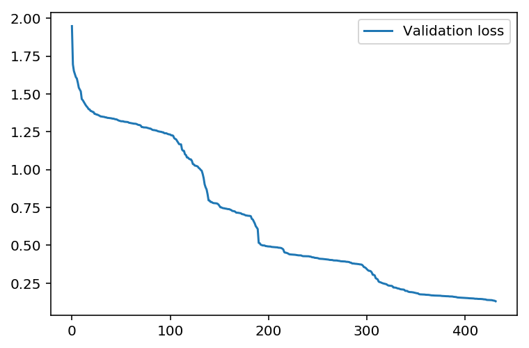

```python
plt.plot(list_valid_losses, label='Validation loss')
plt.legend()
```

```python
range_loss = 1.9490 - 0.1304
print(range_loss)
```

```
1.8186
```

```python
# IDIOT: Used a function name for a variable name :(
reset_selective range
```

```
Once deleted, variables cannot be recovered. Proceed (y/[n])?  y
```

#### Brief discussion of results

**Note:** This training used *stochastic* gradient descent and each parameter set was run *only once*, so the results should be considered random and interpreted only *in general terms*.

**Note:** The last value of the validation loss is taken to represent the parameter set but this is not necessarily the lowest value achieved by the set. There can be overfitting causing the validation loss to start growing after achieving its minimum.

Of the 432 parameter combinations, the lowest validation loss of **0.1304** is achieved for *hidden, learning rate, iterations = 3, 0.1, 100000* and the highest loss of **1.9490** is achieved for *hidden, learning rate, iterations = 3, 0.001, 100*. The range of 1.8186 is not very significant, indicating that this model, that is, the model's structure, is *at the limit of its abilities to capture the patterns of the dataset*. Clearly, any further tweaking of the hyperparameters is not going to yield significantly better predictions.

The expected *inverse relationship between learning rate and training iterations* is clearly visible from the data: we get nearly the same validation loss for parameter sets (n, 10^(-x), 10^x). There is a similar but less clear inverse relationship between number of hidden nodes and number of iterations.

The prevalence of `n=3|4` and `lr=0.1` in the top 20 suggests that these are very reasonable values for the two hyperparameters. The higher numbers of iterations are likely to mitigate the randomization effect of SGD.

#### Examination of training dynamics

Below are shown the training dynamics for a sampling of the parameter sets. Discussion in the comments.

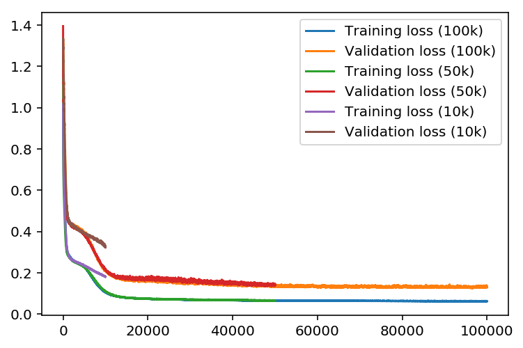

```python
# Training dynamics for the top parameter set (n=3, lr=0.1, iter=100,000)
losses100k = all_losses[(3, 0.1, 100000)]
losses50k = all_losses[(3, 0.1, 50000)]
losses10k = all_losses[(3, 0.1, 10000)]
plt.plot(losses100k['train'], label='Training loss (100k)')
plt.plot(losses100k['validation'], label='Validation loss (100k)')
plt.plot(losses50k['train'], label='Training loss (50k)')
plt.plot(losses50k['validation'], label='Validation loss (50k)')
plt.plot(losses10k['train'], label='Training loss (10k)')
plt.plot(losses10k['validation'], label='Validation loss (10k)')
plt.legend()
_ = plt.ylim()
```

```python
print(validation_losses[(3, 0.1, 100000)])
print(validation_losses[(3, 0.1, 50000)])
print(validation_losses[(3, 0.1, 10000)])
```

```
0.130414541983
0.1384756201
0.328530440364
```

##### Commentary

*Clearly, the number of iterations is excessive. There is little decrease in validation loss between 50K and 100K. On the other hand, 10K is clearly not enough.*

*The apparent thickness of the lines is actually oscillation due to SGD.*

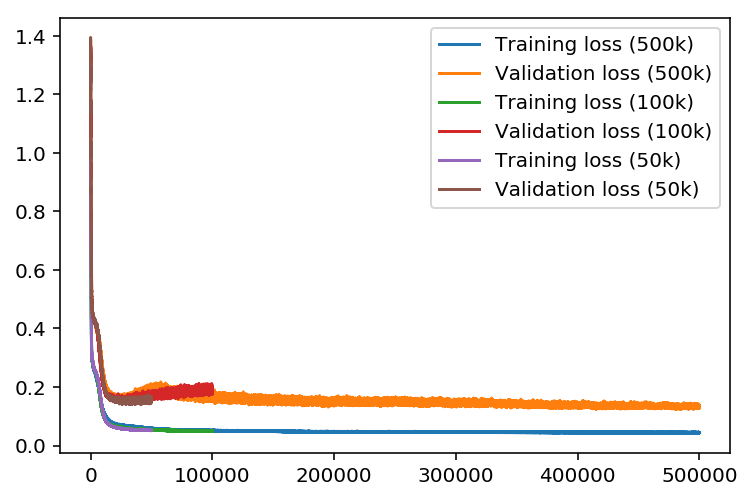

```python
# Training dynamics for the top parameter set (n=3, lr=0.1, iter=100,000)
losses500k = all_losses[(10, 0.1, 500000)]
losses100k = all_losses[(10, 0.1, 100000)]
losses50k = all_losses[(10, 0.1, 50000)]
plt.plot(losses500k['train'], label='Training loss (500k)')
plt.plot(losses500k['validation'], label='Validationv loss (500k)')
plt.plot(losses100k['train'], label='Training loss (100k)')
plt.plot(losses100k['validation'], label='Validation loss (100k)')
plt.plot(losses50k['train'], label='Training loss (50k)')
plt.plot(losses50k['validation'], label='Validation loss (50k)')
plt.legend()
_ = plt.ylim()
```

```python
print(validation_losses[(10, 0.1, 500000)])
print(validation_losses[(10, 0.1, 100000)])
print(validation_losses[(10, 0.1, 50000)])
print(validation_losses[(10, 0.1, 10000)])
```

```
0.13615909619
0.189274819152
0.154033906902
0.255364160323
```

##### Commentary

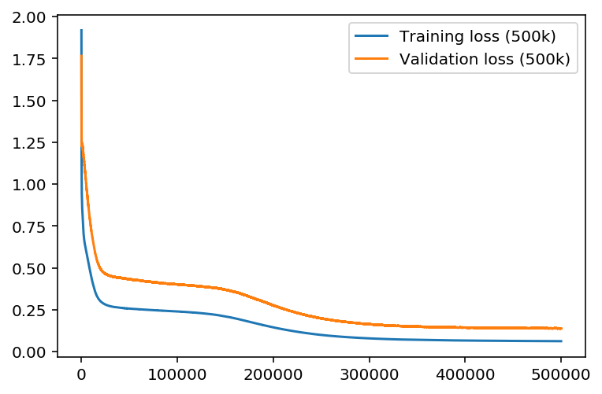

```python
# let's try one more from among the top performing parameter sets
losses500k = all_losses[(4, 0.005, 500000)]
plt.plot(losses500k['train'], label='Training loss (500k)')
plt.plot(losses500k['validation'], label='Validation loss (500k)')
plt.legend()
_ = plt.ylim()
```

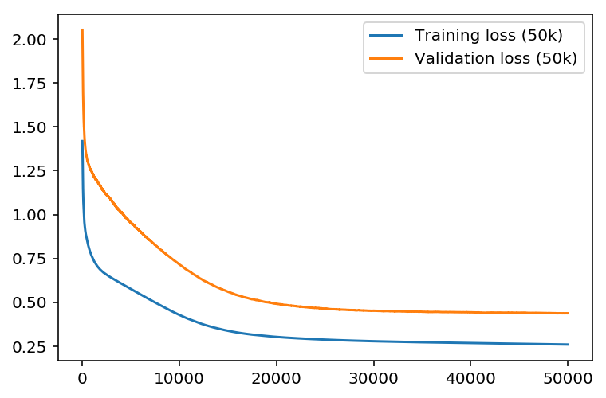

```python
# let's try one more from among the top performing parameter sets
losses50k = all_losses[(4, 0.005, 50000)]
plt.plot(losses50k['train'], label='Training loss (50k)')
plt.plot(losses50k['validation'], label='Validation loss (50k)')
plt.legend()
_ = plt.ylim()
```

```python
print(validation_losses[(4, 0.005, 500000)])
print(validation_losses[(4, 0.005, 100000)])
print(validation_losses[(4, 0.005, 50000)])
print(validation_losses[(4, 0.005, 10000)])
```

```
0.138921850469
0.385778630152
0.437487554768
0.786684890469
```

##### Commentary

*This set does not overfit, due to the reasonable number of nodes and the very low learning rate. In addition, the oscillations caused by SGD are almost nonexistent, again due to the low learning rate.*

*On the flip side, the low learning rate clearly requires a large number of iterations to approach the overall validation loss minimum.*

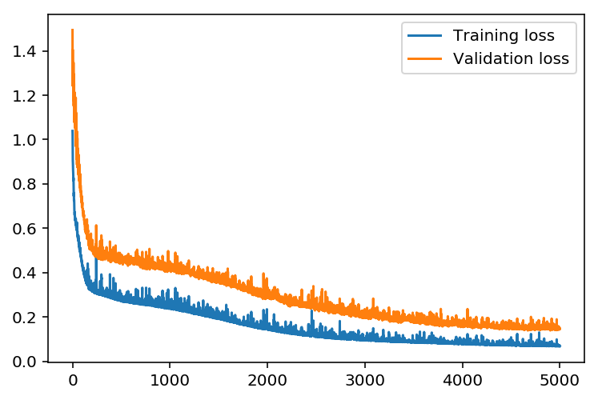

```python
# let's try one more from among the top performing parameter sets
losses = all_losses[(10, 0.5, 5000)]
plt.plot(losses['train'], label='Training loss')
plt.plot(losses['validation'], label='Validation loss')
plt.legend()
_ = plt.ylim()
```

```python
print(validation_losses[(4, 0.5, 5000)])
print(validation_losses[(4, 0.5, 10000)])
print(validation_losses[(4, 0.5, 50000)])
```

```
0.172499101954
0.149366626657
0.175857133938
```

##### Commentary

*This set does not overfit, due to the low number of iterations. The validation loss is decent but can be improved by a larger number of iterations. The number has to be tuned well to avoid the inevitable overfitting at this high learning rate.*

*The high learning rate causes oscillations with an amplitude of 0.1.*

## Check out your predictions

Here, use the test data to view how well your network is modeling the data. If something is completely wrong here, make sure each step in your network is implemented correctly.

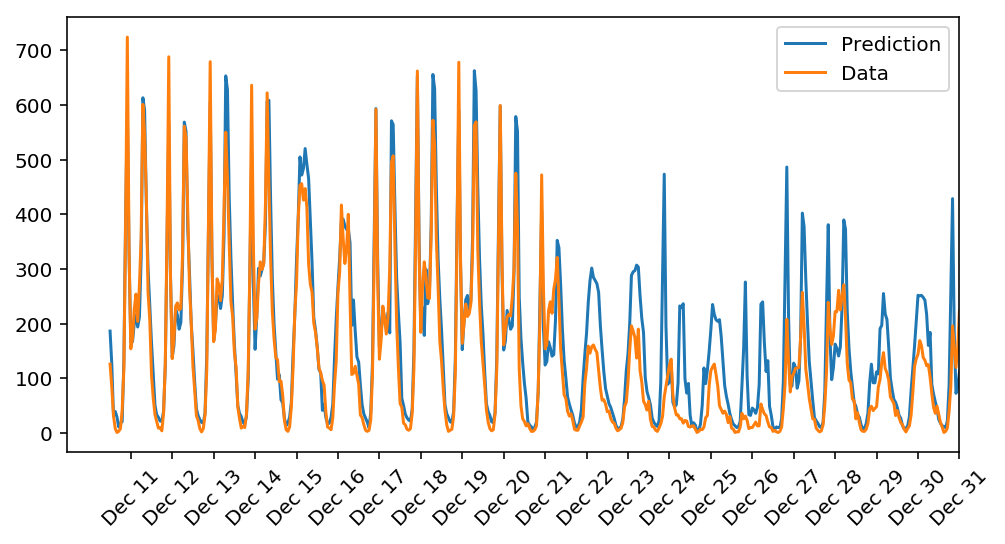

```python
fig, ax = plt.subplots(figsize=(8,4))

network = all_losses[(3, 0.1, 100000)]['network']

mean, std = scaled_features['cnt']
predictions = network.run(test_features).T*std + mean
ax.plot(predictions.values.T, label='Prediction')
ax.plot((test_targets['cnt']*std + mean).values, label='Data')
ax.set_xlim(right=len(predictions))
ax.legend()

dates = pd.to_datetime(rides.iloc[test_data.index]['dteday'])
dates = dates.apply(lambda d: d.strftime('%b %d'))
ax.set_xticks(np.arange(len(dates))[12::24])
_ = ax.set_xticklabels(dates[12::24], rotation=45)
```

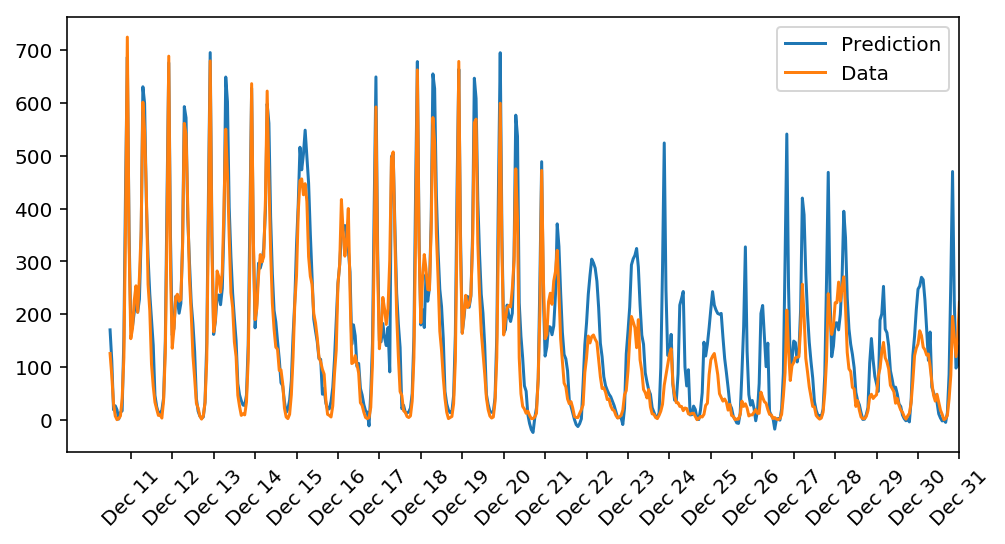

```python
fig, ax = plt.subplots(figsize=(8,4))

network = all_losses[(10, 0.1, 500000)]['network']

mean, std = scaled_features['cnt']
predictions = network.run(test_features).T*std + mean
ax.plot(predictions.values.T, label='Prediction')
ax.plot((test_targets['cnt']*std + mean).values, label='Data')
ax.set_xlim(right=len(predictions))
ax.legend()

dates = pd.to_datetime(rides.iloc[test_data.index]['dteday'])
dates = dates.apply(lambda d: d.strftime('%b %d'))
ax.set_xticks(np.arange(len(dates))[12::24])
_ = ax.set_xticklabels(dates[12::24], rotation=45)
```

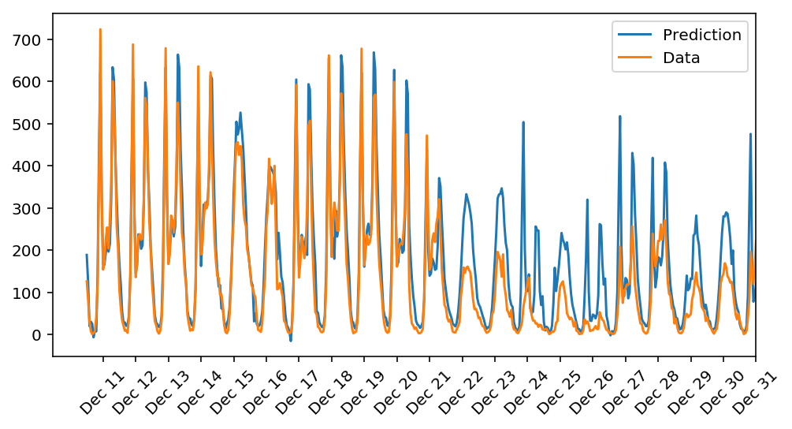

```python
fig, ax = plt.subplots(figsize=(8,4))

network = all_losses[(4, 0.005, 500000)]['network']

mean, std = scaled_features['cnt']
predictions = network.run(test_features).T*std + mean
ax.plot(predictions.values.T, label='Prediction')
ax.plot((test_targets['cnt']*std + mean).values, label='Data')
ax.set_xlim(right=len(predictions))
ax.legend()

dates = pd.to_datetime(rides.iloc[test_data.index]['dteday'])
dates = dates.apply(lambda d: d.strftime('%b %d'))
ax.set_xticks(np.arange(len(dates))[12::24])
_ = ax.set_xticklabels(dates[12::24], rotation=45)
```

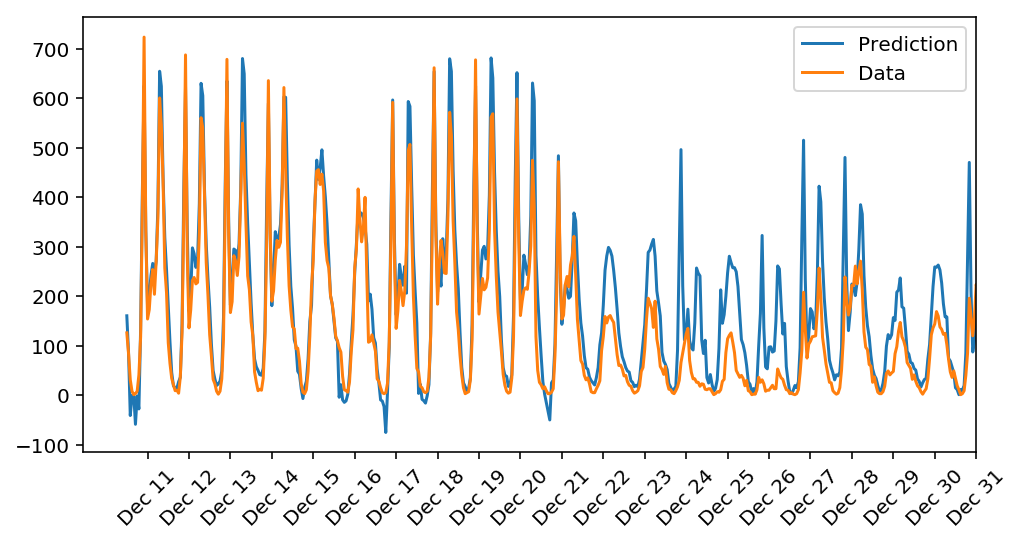

```python
fig, ax = plt.subplots(figsize=(8,4))

network = all_losses[(10, 0.5, 5000)]['network']

mean, std = scaled_features['cnt']
predictions = network.run(test_features).T*std + mean
ax.plot(predictions.values.T, label='Prediction')
ax.plot((test_targets['cnt']*std + mean).values, label='Data')
ax.set_xlim(right=len(predictions))
ax.legend()

dates = pd.to_datetime(rides.iloc[test_data.index]['dteday'])
dates = dates.apply(lambda d: d.strftime('%b %d'))
ax.set_xticks(np.arange(len(dates))[12::24])
_ = ax.set_xticklabels(dates[12::24], rotation=45)
```

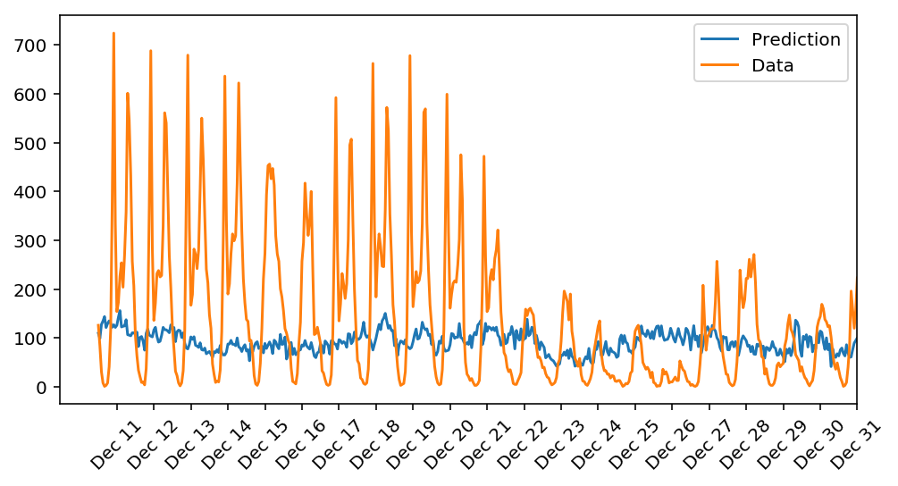

```python
fig, ax = plt.subplots(figsize=(8,4))

network = all_losses[(3, 0.001, 100)]['network']

mean, std = scaled_features['cnt']
predictions = network.run(test_features).T*std + mean
ax.plot(predictions.values.T, label='Prediction')
ax.plot((test_targets['cnt']*std + mean).values, label='Data')
ax.set_xlim(right=len(predictions))
ax.legend()

dates = pd.to_datetime(rides.iloc[test_data.index]['dteday'])
dates = dates.apply(lambda d: d.strftime('%b %d'))
ax.set_xticks(np.arange(len(dates))[12::24])
_ = ax.set_xticklabels(dates[12::24], rotation=45)
```

#### Brief discussion of results

Just for sport, the last prediction plot is from a barely trained network. It's predictions are still very *close to the mean of the training set values*.

## OPTIONAL: Thinking about your results(this question will not be evaluated in the rubric).

Answer these questions about your results. How well does the model predict the data? Where does it fail? Why does it fail where it does?

> **Note:** You can edit the text in this cell by double clicking on it. When you want to render the text, press control + enter

#### Your answer below

The prediction for the first 10-11 days seems very good, but it becomes *unsatisfactory* for the remaining 9-10 days. Possible reasons:

1. This (type of) network is not good for (temporal) sequence modeling.
2. No biases were used in the network so it can't capture complexities in the dataset.
3. It has only one hidden layer which might be insufficient to capture the complexities in the dataset.
4. The training dataset isn't predictive of the test set, that is, the test set contains rental patterns that were not learned during training. There is a clear difference in the weekly rental patterns between the first and second half of the testing dataset.
5. The test set is *"too long"* for the model to predict correctly.

### TODO (time permitting)

1. Compose line plots for learning dynamics, that is, *loss vs some parameter*. This will most clearly show overfitting.
2. (DONE) Surface plot of final training validation errors for parameters.
   - We have 3 parameters (number of hidden nodes, learning rate, and iterations) and one dependent variable: have 6 plots for each of the training rates, each plot having number of nodes and iterations as horizontal dimensions and validation loss as vertical dimension.
   - Detect parameter sets which cause *overfitting*. Look for regions in the space where the validation loss is growing, possibly along one or two dimensions. Check if non-overfitted models perform better on the test set.
   - This is very much akin to predicting stock prices. Explore the approaches.
3. How to tell *overfitting* from *underfitting* for a test set prediction?

#### Parameter space visualization

Using the `mplot3d` toolkit.

Now try to visualize parts of the parameter space. The space has 3 dimensions:

- number of hidden nodes
- learning rate
- number of iterations

The dependent variables are:

- training loss
- *validation loss*
- training loss

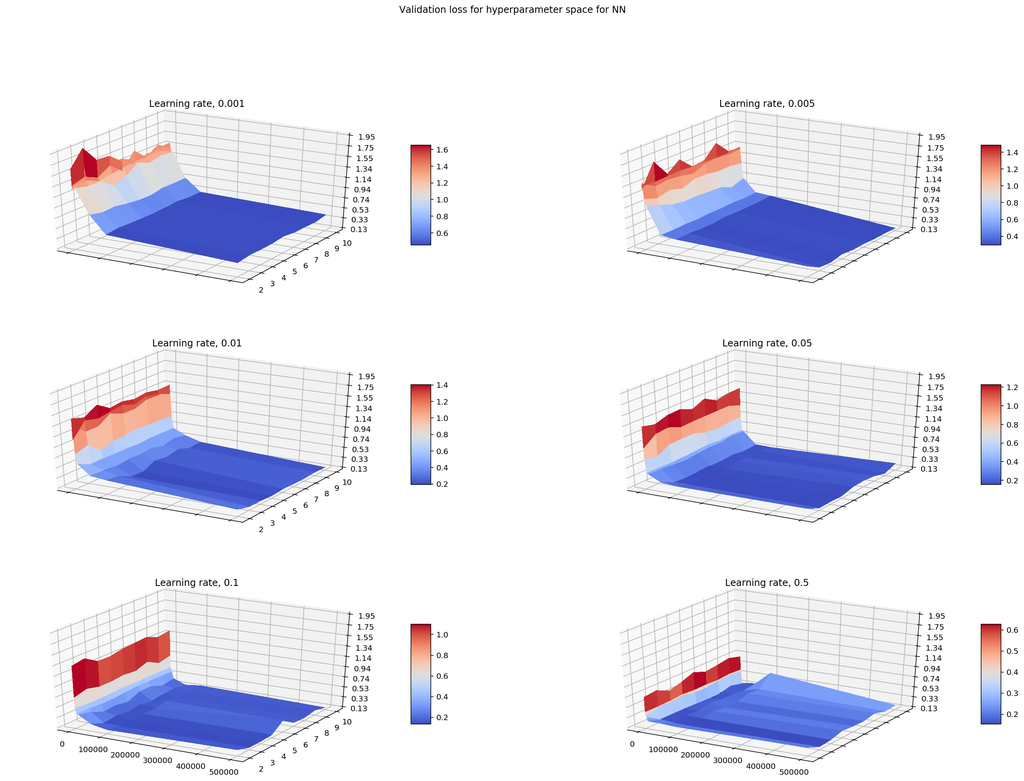

```python
'''
======================
3D surface (color map)
======================

A series of plots to visualize the parameter space.
'''

from mpl_toolkits.mplot3d import Axes3D
import matplotlib.pyplot as plt
from matplotlib import cm
from matplotlib.ticker import LinearLocator, FormatStrFormatter
import numpy as np

fig, axes = plt.subplots(3, 2,
                         sharex='all', sharey='all',
                         subplot_kw=dict(projection='3d'),
                         figsize=(24, 16))

plt.suptitle('Validation loss for hyperparameter space for NN')

# Make data.
X = np.array([100, 500, 1000, 5000, 10000, 50000, 100000, 500000])
Y = np.array([2, 3, 4, 5, 6, 7, 8, 9, 10])
X, Y = np.meshgrid(X, Y)
Z001 = np.zeros( (9, 8) )
Z005 = np.zeros( (9, 8) )
Z01 = np.zeros( (9, 8) )
Z05 = np.zeros( (9, 8) )
Z1 = np.zeros( (9, 8) )
Z5 = np.zeros( (9, 8) )
for i in range(9):
    for j in range(8):
         Z001[i, j] = validation_losses[(Y[i, j], 0.001, X[i, j])]
         Z005[i, j] = validation_losses[(Y[i, j], 0.005, X[i, j])]
         Z01[i, j] = validation_losses[(Y[i, j], 0.01, X[i, j])]
         Z05[i, j] = validation_losses[(Y[i, j], 0.05, X[i, j])]
         Z1[i, j] = validation_losses[(Y[i, j], 0.1, X[i, j])]
         Z5[i, j] = validation_losses[(Y[i, j], 0.5, X[i, j])]


# Plot the surfaces
# 0,0
surf00 = axes[0,0].plot_surface(X, Y, Z001, cmap=cm.coolwarm, linewidth=0, antialiased=False)
axes[0,0].set_zlim(0.13, 1.95)  # Customize z axis
axes[0,0].zaxis.set_major_locator(LinearLocator(10))
axes[0,0].zaxis.set_major_formatter(FormatStrFormatter('%.02f'))
axes[0,0].set_title('Learning rate, 0.001')
fig.colorbar(surf00, ax=axes[0,0], shrink=0.5, aspect=5)  # Add colorbar
# 0,1
surf01 = axes[0,1].plot_surface(X, Y, Z005, cmap=cm.coolwarm, linewidth=0, antialiased=False)
axes[0,1].set_zlim(0.13, 1.95)  # Customize z axis
axes[0,1].zaxis.set_major_locator(LinearLocator(10))
axes[0,1].zaxis.set_major_formatter(FormatStrFormatter('%.02f'))
axes[0,1].set_title('Learning rate, 0.005')
fig.colorbar(surf01, ax=axes[0,1], shrink=0.5, aspect=5)  # Add colorbar

# 1,0
surf10 = axes[1,0].plot_surface(X, Y, Z01, cmap=cm.coolwarm, linewidth=0, antialiased=False)
axes[1,0].set_zlim(0.13, 1.95)  # Customize z axis
axes[1,0].zaxis.set_major_locator(LinearLocator(10))
axes[1,0].zaxis.set_major_formatter(FormatStrFormatter('%.02f'))
axes[1,0].set_title('Learning rate, 0.01')
fig.colorbar(surf10, ax=axes[1,0], shrink=0.5, aspect=5)  # Add colorbar
# 1,1
surf11 = axes[1,1].plot_surface(X, Y, Z05, cmap=cm.coolwarm, linewidth=0, antialiased=False)
axes[1,1].set_zlim(0.13, 1.95)  # Customize z axis
axes[1,1].zaxis.set_major_locator(LinearLocator(10))
axes[1,1].zaxis.set_major_formatter(FormatStrFormatter('%.02f'))
axes[1,1].set_title('Learning rate, 0.05')
fig.colorbar(surf11, ax=axes[1,1], shrink=0.5, aspect=5)  # Add colorbar

# 2,0
surf20 = axes[2,0].plot_surface(X, Y, Z1, cmap=cm.coolwarm, linewidth=0, antialiased=False)
axes[2,0].set_zlim(0.13, 1.95)  # Customize z axis
axes[2,0].zaxis.set_major_locator(LinearLocator(10))
axes[2,0].zaxis.set_major_formatter(FormatStrFormatter('%.02f'))
axes[2,0].set_title('Learning rate, 0.1')
fig.colorbar(surf20, ax=axes[2,0], shrink=0.5, aspect=5)  # Add colorbar
# 2,1
surf21 = axes[2,1].plot_surface(X, Y, Z5, cmap=cm.coolwarm, linewidth=0, antialiased=False)
axes[2,1].set_zlim(0.13, 1.95)  # Customize z axis
axes[2,1].zaxis.set_major_locator(LinearLocator(10))
axes[2,1].zaxis.set_major_formatter(FormatStrFormatter('%.02f'))
axes[2,1].set_title('Learning rate, 0.5')
fig.colorbar(surf21, ax=axes[2,1], shrink=0.5, aspect=5)  # Add colorbar

# Draw
plt.show()
```

##### Commentary

The lower learning rates cause more gently sloping and smoother surfaces. The higher learning rates show a sharper drop in the beginning but various wavy artifacts along both horizontal axes (iterations and number of hidden nodes).